# Debuging `sceptre` 5: Understanding Papalexi and MIMOSCA

Tim

2022-10-15

This is the fifth installment of the debugging SCEPTRE series. I aim to answer the following questions.

# Part 1: SCEPTRE exhibits better calibration on the Papalexi data than the Frangieh data. Also, applying QC improves the calibration quality of SCEPTRE on the Frangieh data but not on the Papalexi data.

I begin by comparing the SCEPTRE results obtained on the Frangieh data to those obtained on the Papalexi data. I downsample the set of Frangieh pairs so that the Frangieh data contain the same number of pairs as the Papalexi data. SCEPTRE clearly exhibits better calibration on the Papalexi data than on the Frangieh data.

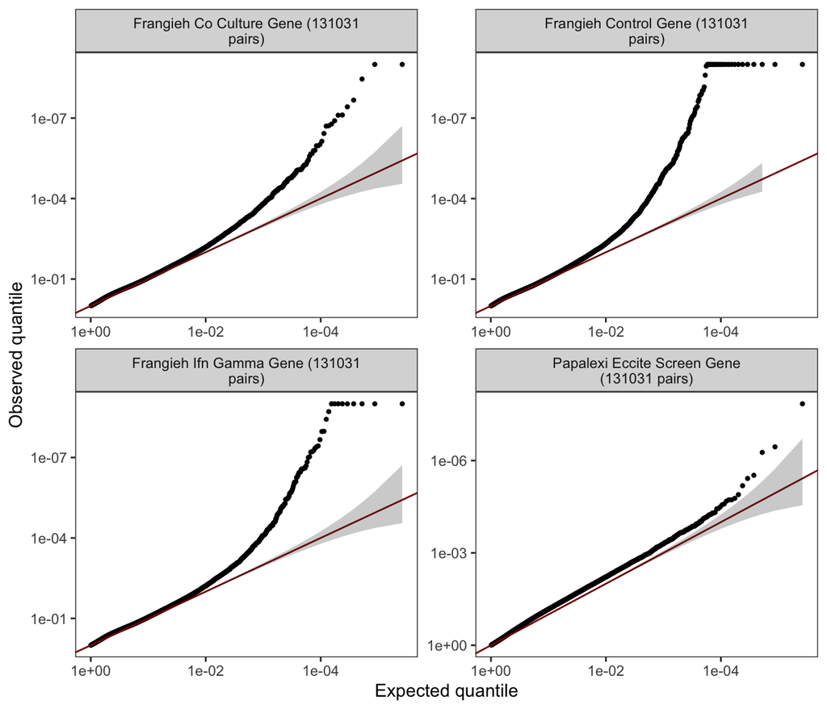

Next, for each dataset, I plot the pairs that pass QC alongside the pairs that do not. The comparison here is along two axes: first, across datasets, and second, within a given dataset, across pairs that passed QC versus pairs that did not. To enable meaningful comparisons along both axes, I performed downsampling so that each dataset-QC status (i.e., passed versus not passed) tuple would contain the same number of pairs. In other words, I performed downsampling so that each of the eight sets of pairs below (two for each of the four plots) would have the same number of pairs.

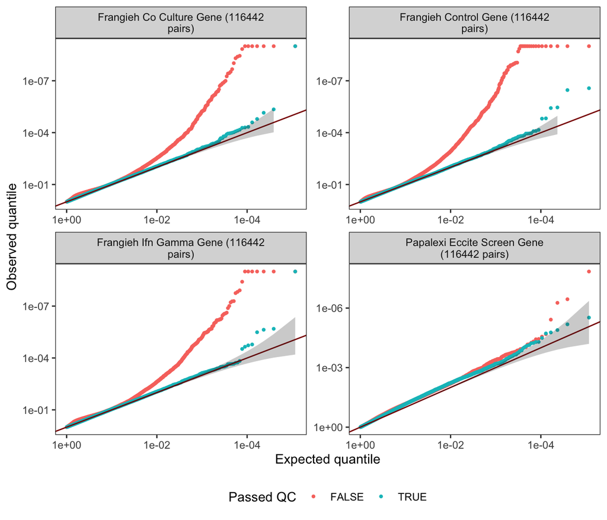

We see that QC makes an enormous difference on the Frangieh data: the pairs that survive QC are fairly well calibrated, while those that are filtered out are poorly calibrated. By contrast, QC does not make much of a difference on the Papalexi data: the pairs that pass QC and those that do not are both fairly well-calibrated.

Next, I make a similar figure, this time plotting pairs with a “good” skew-normal fit alongside those with a “bad” (i.e., not “good”) skew-normal fit. Again, I downsample so that each dataset-skew-normal fit status (i.e., “good” versus “bad”) tuple contains the same number of pairs. Note that the number of pairs plotted below is much smaller than the number of pairs plotted above; thus, we are not looking as far out into the tail of the distribution. Still, the trend is clear: SCEPTRE exhibits similar performance on the Papalexi data regardless of whether the skew-normal fit is good or bad. By contrast, on the Frangieh data, a good skew-normal fit is required for p-value calibration.

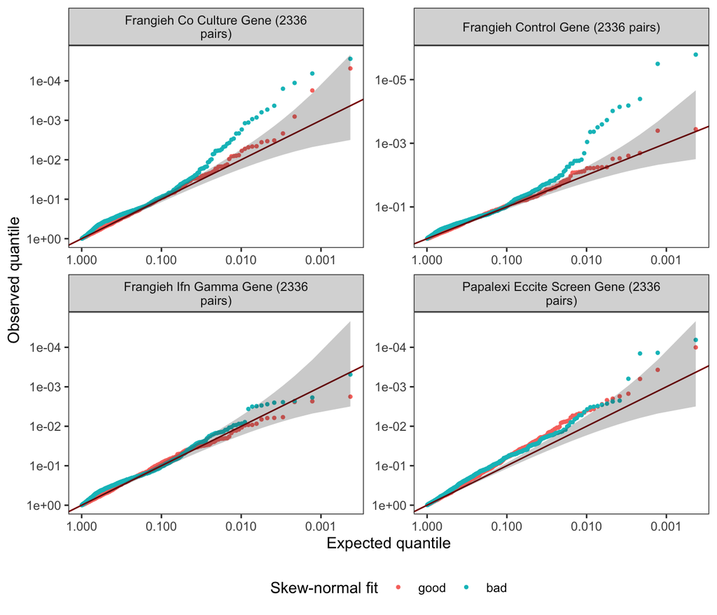

These two sets of results are concordant: on the Frangieh and Papalexi datasets, almost all of the variance in skew-normal fit quality is due to the effective sample size. Thus, pairs that pass QC tend to exhibit a good skew-normal fit, and conversely, pairs that are filtered tend to exhibit a bad skew-normal fit. In conclusion, a large effective sample size (or, roughly equivalently, a good skew-normal fit) is required for SCEPTRE to exhibit good calibration on the Frangieh data but not on the Papalexi data.

# Part 2: Why do the Papalexi and Frangieh datasets differ in this way?

I attempt to answer the following questions: Why on the Papalexi data does effective sample size not impact calibration quality? Put differently, how can pairs with a low effective sample size (and thus a poor skew-normal fit) exhibit good calibration? And why does this phenomenon not hold on the Frangieh data?

First, to get our bearings, I plot some of the SCEPTRE resampling distributions on the Papalexi data that fall into the “good,” “adequate,” “subpar,” and “poor” categories. Here are four pairs in the **good** category:

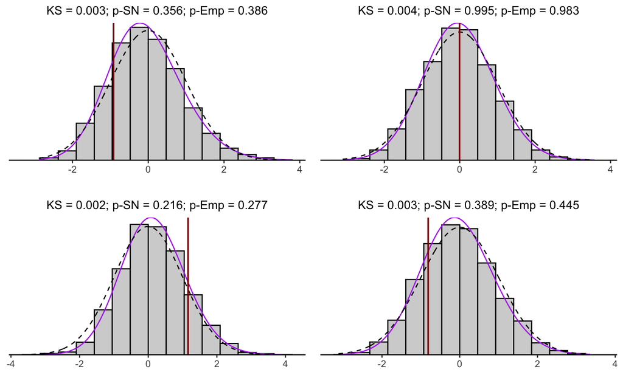

Here are four in the **adequate** category:

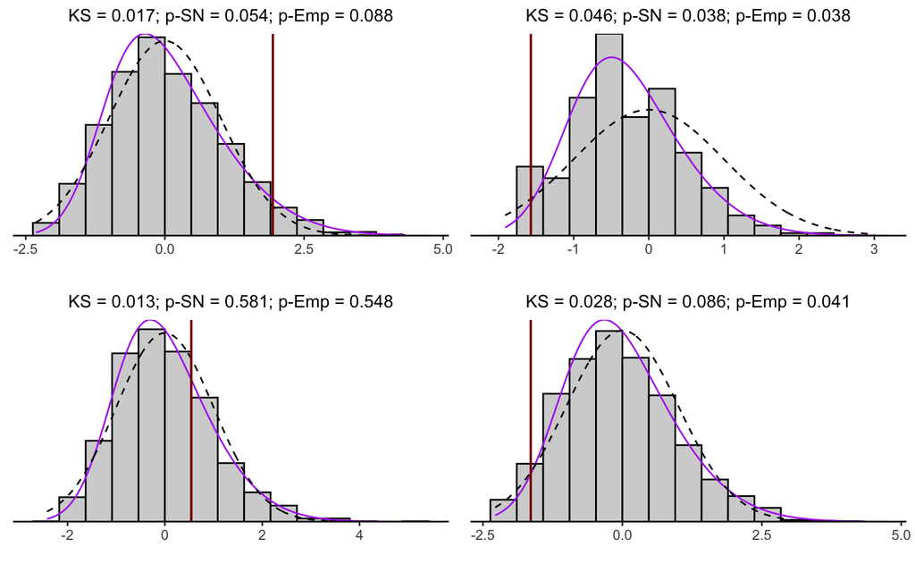

Here are four in the **subpar** category.

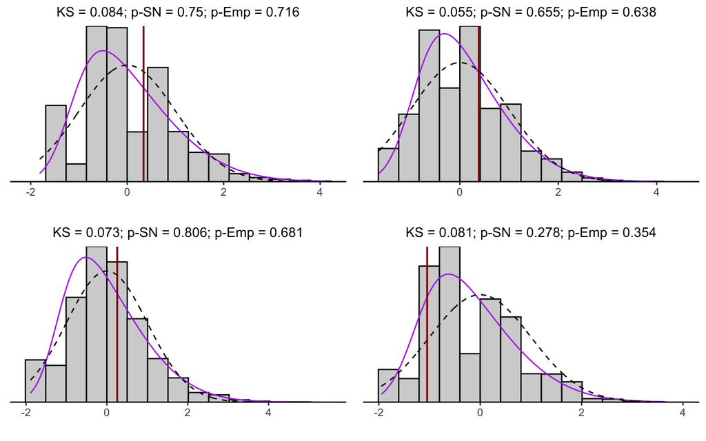

Finally, here are eight in the **poor** category.

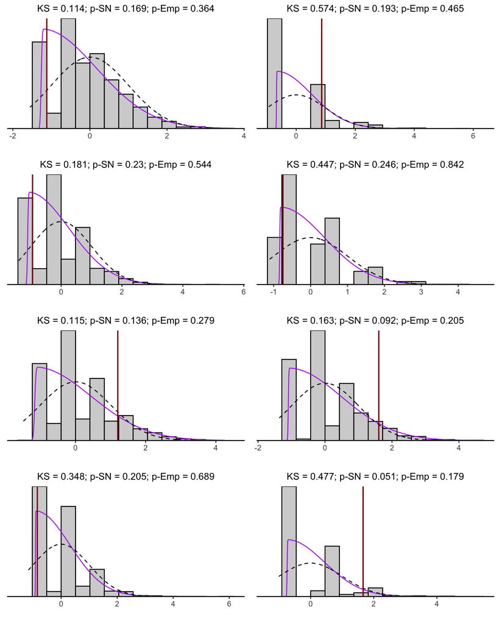

For comparison, I plot eight resampling distributions in the **poor** category from the Frangieh co-culture data.

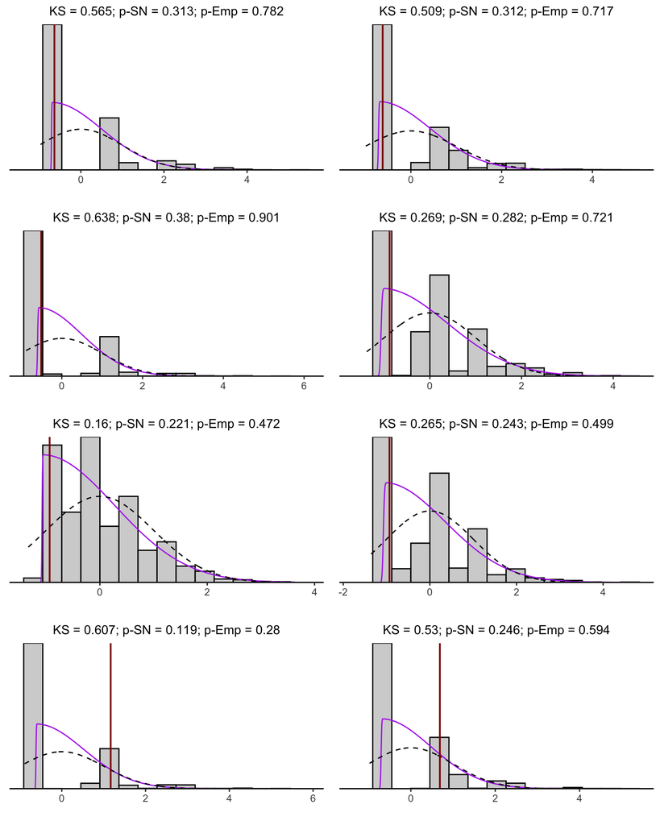

The Papalexi null distributions are less “lumpy” and multimodal than the Frangieh null distributions. Inflation occurs when there is a “lump” far out into the tail of the distribution, and this seems to be a more common occurrence on the Frangieh data than on the Papalexi data.

I compute $p_{rat}$, the ratio of the skew-normal p-value to the empirical p-value on the Frangieh and Papalexi datasets. I downsample the Frangieh datasets so that all datasets have the same number of pairs to facilitate comparisons.

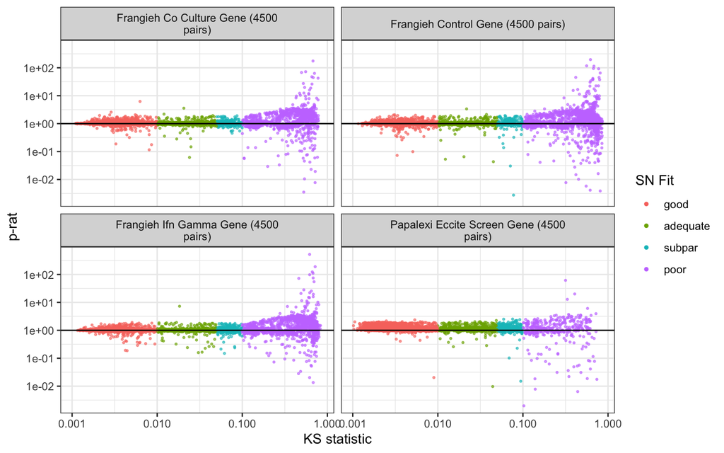

Points above one indicate inflation. The Papalexi data do not have many points far above one, whereas the Frangieh data do. Furthermore, the Frangieh data have many more “poor” pairs than Papalexi. These two factors together likely explain the phenomena that we observe.

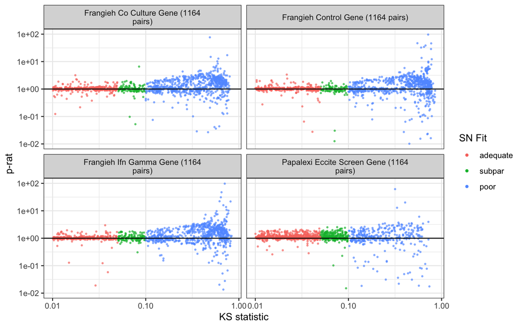

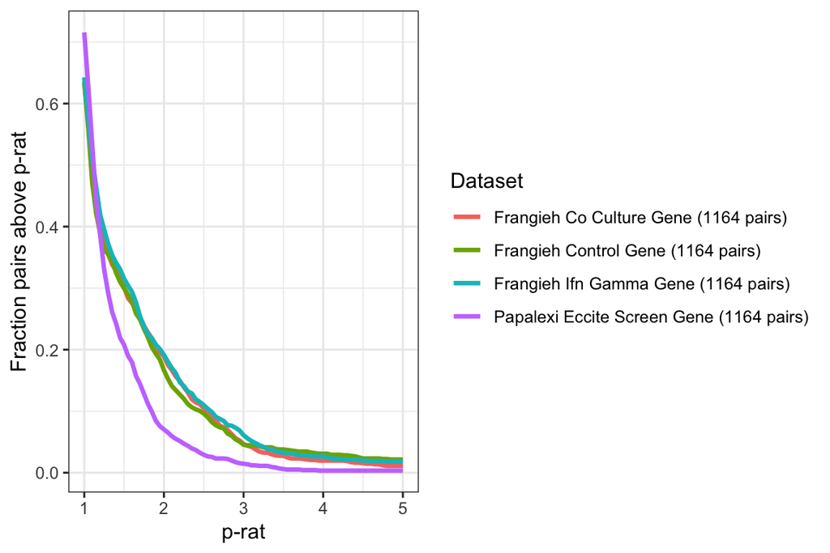